# Introduction to SBM and LBM. Practice

Sophie Donnet & Sarah Ouadah

Juillet 2020

# Dataset : fungus-tree interactions

VACHER, C., PIOU, D. and DESPREZ-LOUSTAU, M.-L. (2008). Architecture of an antagonistic tree/fungus network: The asymmetric influence of past evolutionary history. PLoS ONE 3 1740.

```r
rm(list=ls())
load('fungi_tree_data.Rdata')
ls()
```

```
## [1] "fungi_list" "fungi_tree" "ListVar"    "tree"       "tree_bin"
## [6] "tree_list"
```

- $154$ fungi species, $51$ tree species
- “fungi_list”: list of fungal species names
- “tree_list” : list of trees species names
- “tree_bin” : binary tree-tree interactions ($1$ if hosting at least one common fungal species, $0$ otherwise)
- “tree” : weighted tree-tree interactions (number of common fungal species two tree species host)
- “ListVar” : covariates discribing pairs of trees (genetic, taxonomic and geographic distances)
- “fungi_tree” : binary fungus-tree interactions

# Useful packages

- R-package blockmodels to infer Stochastic Block Model [SBM] and Latent Block model [LBM] on ecological networks

```r
library(devtools)
install_github("GrossSBM/sbm")
```

(skip updates of dependecies if you have troubles)

```r
library(sbm)
```

GSBM is a common interface for all the pacakges developed in our unity (and friends) and dealing with the topological inference for complex networks. We use unified notations.

- We will also need the ggplot2, igraph and alluvial packages for the graphical representations.

```r
library(ggplot2)
library(igraph)
library(alluvial)
```

# Stochastic Block Model for Binary Network

## Dataset : binary tree-tree interactions

We consider that two trees are in interaction if they host at least one common fungal species.

- Plot of the adjacency matrix:

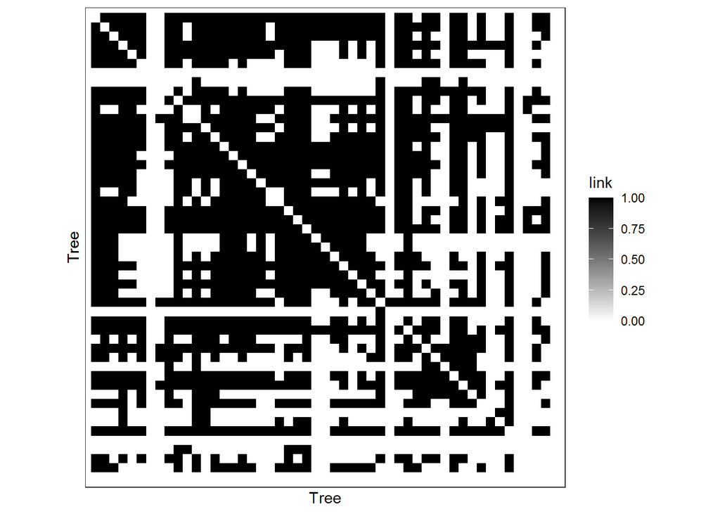

```r
plotMyMatrix(tree_bin,rowLabel = 'Tree', colLabel = 'Tree')
```

## Model and inference

$$\begin{align*}
(Z_i) \text{ i.i.d.} \qquad & Z_i \sim \mathcal{M}(1, \pi) \\
(Y_{ij}) \text{ indep.} \mid (Z_i) \qquad & (Y_{ij} \mid Z_i=k, Z_j = \ell) \sim \mathcal{B}(\alpha_{k\ell})
\end{align*}$$

simpleSBM refers to standard networks (w.r.t. bipartite)

- Then we apply the inference method

```r
sbm.tree_bin <- estimateSimpleSBM(
  tree_bin,
  model = "bernoulli", directed = FALSE
)
```

```
## -> Estimation for 1 groups
##
```

```
## -> Computation of eigen decomposition used for initalizations
##
## -> Pass 1
##     -> With ascending number of groups
##         -> For 2 groups
##
```

```
##         -> For 3 groups
##
```

```
##         -> For 4 groups
##
```

```
##         -> For 5 groups
##
```

```
##         -> For 6 groups
##
```

```
##         -> For 7 groups
##
```

```
##         -> For 8 groups
##
```

```
##     -> With descending number of groups
##         -> For 7 groups
##
```

```
##         -> For 6 groups
##
```

```
##         -> For 5 groups
##
```

```
##         -> For 4 groups
##
```

```
##         -> For 3 groups
##
```

```
##         -> For 2 groups
##
```

```
## -> Pass 2
##     -> With ascending number of groups
##         -> For 2 groups
##         -> For 3 groups
##         -> For 4 groups
##         -> For 5 groups
##
```

```
##         -> For 6 groups
##
```

```
##         -> For 7 groups
##         -> For 8 groups
##     -> With descending number of groups
##         -> For 7 groups
##         -> For 6 groups
##         -> For 5 groups
##         -> For 4 groups
##         -> For 3 groups
##         -> For 2 groups
```

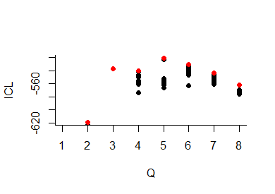

- The various points correspond to several runs of the estimation (resulting into a model selection criteria value) for a given number of clusters (denoted $Q$ here).
- The GSBM returns the better model (number of blocks selected with respect to the ICL criteria).

```r
sbm.tree_bin$nbBlocks
```

```
## [1] 5
```

- We can now extract the parameters of interest, namely (`sbm.tree_bin$connectParam$mu`, $\alpha$, `sbm.tree_bin$blockProp` $\pi$) and the nodes (here tree species) clustering $Z$ (`sbm.tree_bin$memberships`)

```r
sbm.tree_bin$blockProp
```

```
## [1] 0.2737836 0.2349327 0.1572832 0.1573006 0.1766999
```

```r
sbm.tree_bin$connectParam$mu
```

[output not shown]

```r
sbm.tree_bin$memberships
```

```
##  [1] 1 1 1 2 2 4 5 5 4 1 4 2 2 2 1 1 1 1 3 4 3 1 1 1 3 3 3 1 3 1 3 2 5 2 1 4 2 4
## [39] 5 2 2 4 2 5 5 2 5 5 4 3 5
```

- One can plot the reorganized matrix according to the clustering.

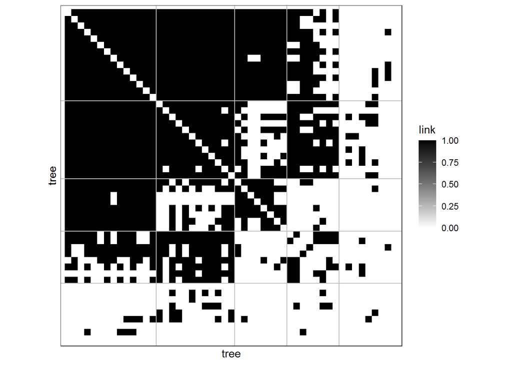

```r
plot(sbm.tree_bin,type = 'data',ordered = TRUE,colLabel = 'tree', rowLabel = 'tree' )
```

- Finally one can plot the macroview of the network.

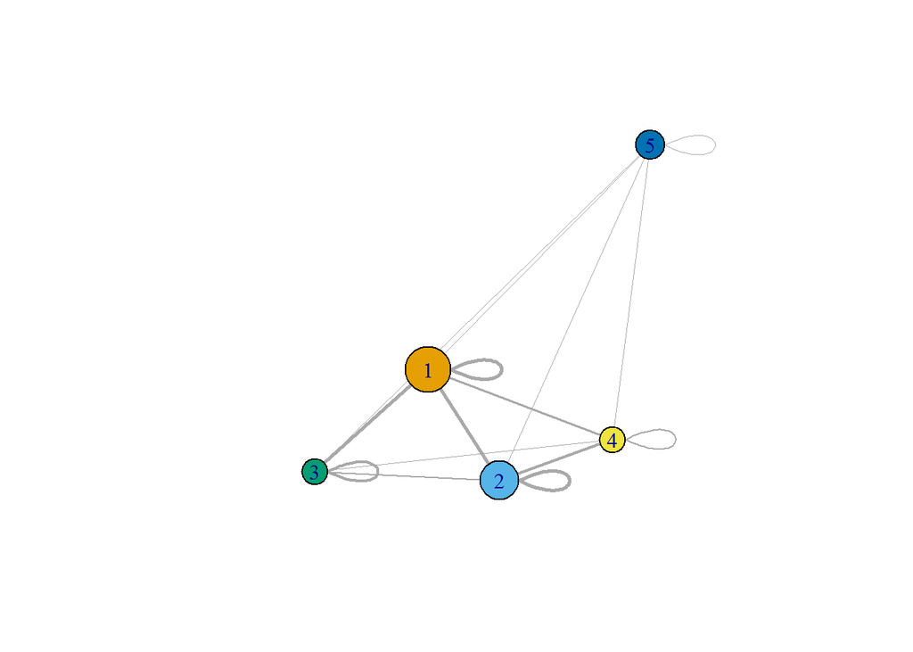

```r
G <- graph_from_adjacency_matrix(sbm.tree_bin$connectParam$mean, mode = c("undirected"), weighted = TRUE, diag = TRUE)
plot.igraph(G,vertex.size=sbm.tree_bin$blockProp*100,edge.width=abs(E(G)$weight)*3,vertex.color = 1:sbm.tree_bin$nbBlocks, layout = layout_nicely)
```

- The composition of the clusters/blocks are given by:

```r
lapply(1:sbm.tree_bin$nbBlocks,function(q){tree_list[sbm.tree_bin$memberships == q]})
```

```
## [[1]]
##  [1] Abies alba
##  [2] Abies grandis
##  [3] Abies nordmanniana
##  [4] Cedrus spp (Cedrus atlantica, Cedrus libani)
##  [5] Larix decidua
##  [6] Larix kaempferi
##  [7] Picea excelsa
##  [8] Picea sitchensis
##  [9] Pinus nigra laricio
## [10] Pinus nigra nigra
## [11] Pinus pinaster
## [12] Pinus sylvestris
## [13] Pinus uncinata
## [14] Pseudotsuga menziesii
```

[output cut: 50 more lines]

# SBM for Counting Network

## Dataset : weighted tree-tree interactions

In the weighted tree-tree interactions network, each edge is valued with the number of common fungal species two tree species can host.

- Plot of the adjacency matrix:

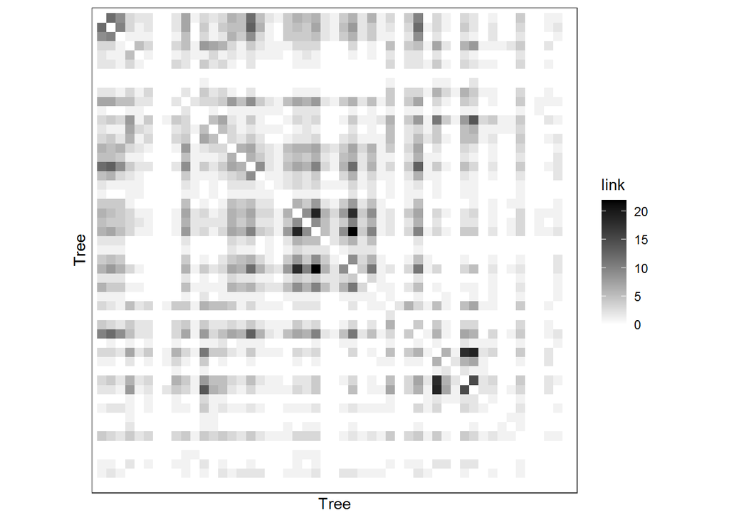

```r
plotMyMatrix(tree,rowLabel = 'Tree', colLabel = 'Tree')
```

## Model and inference

We consider the SBM Poisson model.

$$\begin{align*}
(Z_i) \text{ i.i.d.} \qquad & Z_i \sim \mathcal{M}(1, \pi) \\
(Y_{ij}) \text{ indep.} \mid (Z_i) \qquad & (Y_{ij} \mid Z_i=k, Z_j = \ell) \sim \mathcal{P}(\exp(\alpha_{kl})) = \mathcal{P}(\lambda_{kl})
\end{align*}$$

```r
sbm.tree <- estimateSimpleSBM(
  tree,
  model = "poisson", directed = FALSE
)
```

```
## -> Estimation for 1 groups
##
```

```
## -> Computation of eigen decomposition used for initalizations
##
## -> Pass 1
##     -> With ascending number of groups
##         -> For 2 groups
##
```

```
##         -> For 3 groups
##
```

```
##         -> For 4 groups
##
```

```
##         -> For 5 groups
##
```

```
##         -> For 6 groups
##
```

```
##         -> For 7 groups
##
```

```
##         -> For 8 groups
##
```

```
##         -> For 9 groups
##
```

```
##         -> For 10 groups
##
```

```
##         -> For 11 groups
##
```

```
##     -> With descending number of groups
##         -> For 10 groups
##
```

```
##         -> For 9 groups
##
```

```
##         -> For 8 groups
##
```

```
##         -> For 7 groups
##
```

```
##         -> For 6 groups
##
```

```
##         -> For 5 groups
##
```

```
##         -> For 4 groups
##
```

```
##         -> For 3 groups
##
```

```
##         -> For 2 groups
##
```

```
## -> Pass 2
##     -> With ascending number of groups
##         -> For 2 groups
##         -> For 3 groups
##
```

```
##         -> For 4 groups
##
```

```
##         -> For 5 groups
##         -> For 6 groups
##         -> For 7 groups
##
```

```
##         -> For 8 groups
##
```

```
##         -> For 9 groups
##
```

```
##         -> For 10 groups
##
```

```
##         -> For 11 groups
##     -> With descending number of groups
##         -> For 10 groups
##         -> For 9 groups
##         -> For 8 groups
##         -> For 7 groups
##         -> For 6 groups
##         -> For 5 groups
##         -> For 4 groups
##         -> For 3 groups
##         -> For 2 groups
## -> Pass 3
##     -> With ascending number of groups
##         -> For 2 groups
##         -> For 3 groups
##         -> For 4 groups
##         -> For 5 groups
##         -> For 6 groups
##         -> For 7 groups
##         -> For 8 groups
##         -> For 9 groups
##         -> For 10 groups
##         -> For 11 groups
##     -> With descending number of groups
##         -> For 10 groups
##         -> For 9 groups
##         -> For 8 groups
##         -> For 7 groups
##         -> For 6 groups
##         -> For 5 groups
##         -> For 4 groups
##         -> For 3 groups
##         -> For 2 groups
```

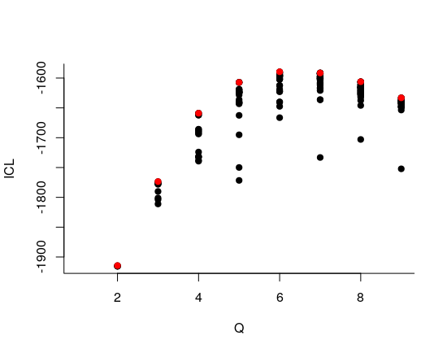

- We obtain the best numbers of clusters (with respect to the ICL criteria)

```r
sbm.tree$nbBlocks
```

```
## [1] 7
```

- We can now extract the parameters of interest, namely ($\lambda$, $\pi$) and the clustering of the nodes.

```r
sbm.tree$blockProp
```

```
## [1] 0.17596562 0.07930706 0.13737914 0.11798972 0.13733105 0.15667238 0.19535504
```

```r
sbm.tree$connectParam$mu
```

[output not shown]

```r
sbm.tree$memberships
```

```
##  [1] 1 1 3 4 5 5 7 7 5 1 6 2 4 4 1 3 1 3 6 6 3 1 3 1 6 6 3 1 6 3 6 4 7 4 1 5 2 5
## [39] 7 2 2 7 5 7 7 4 7 7 5 6 7
```

- One can plot the reorganized matrix according to the clustering.

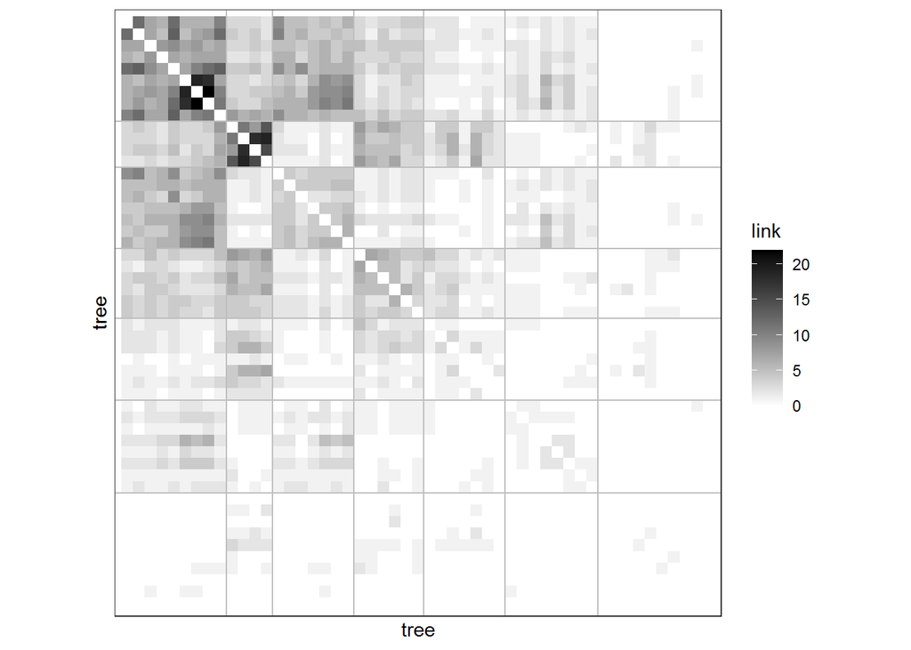

```r
plot(sbm.tree,type = 'data',ordered = TRUE,colLabel = 'tree', rowLabel = 'tree' )
```

```r
G <- graph_from_adjacency_matrix(sbm.tree$connectParam$mean, mode = c("undirected"), weighted = TRUE, diag = TRUE)
plot.igraph(G,vertex.size=sbm.tree$blockProp*100,edge.width=abs(E(G)$weight)*3,vertex.color=1:sbm.tree$nbBlocks, layout=layout_nicely)
```

[output not shown]

- The composition of the clusters/blocks are given by :

```r
lapply(1:sbm.tree$nbBlocks,function(q){tree_list[sbm.tree$memberships == q]})
```

```
## [[1]]
## [1] Abies alba
## [2] Abies grandis
## [3] Cedrus spp (Cedrus atlantica, Cedrus libani)
## [4] Larix decidua
## [5] Picea excelsa
## [6] Pinus nigra laricio
## [7] Pinus pinaster
## [8] Pinus sylvestris
## [9] Pseudotsuga menziesii
## 51 Levels: Abies alba Abies grandis Abies nordmanniana ... Ulmus spp (Ulmus minor, Ulmus laevis, Ulmus glabra)
##
## [[2]]
## [1] Fagus silvatica Quercus petraea Quercus robur   Quercus rubra
## 51 Levels: Abies alba Abies grandis Abies nordmanniana ... Ulmus spp (Ulmus minor, Ulmus laevis, Ulmus glabra)
```

[output cut: 48 more lines]

We are interested in comparing the two cluterings. To do so we use the alluvial flow plots.

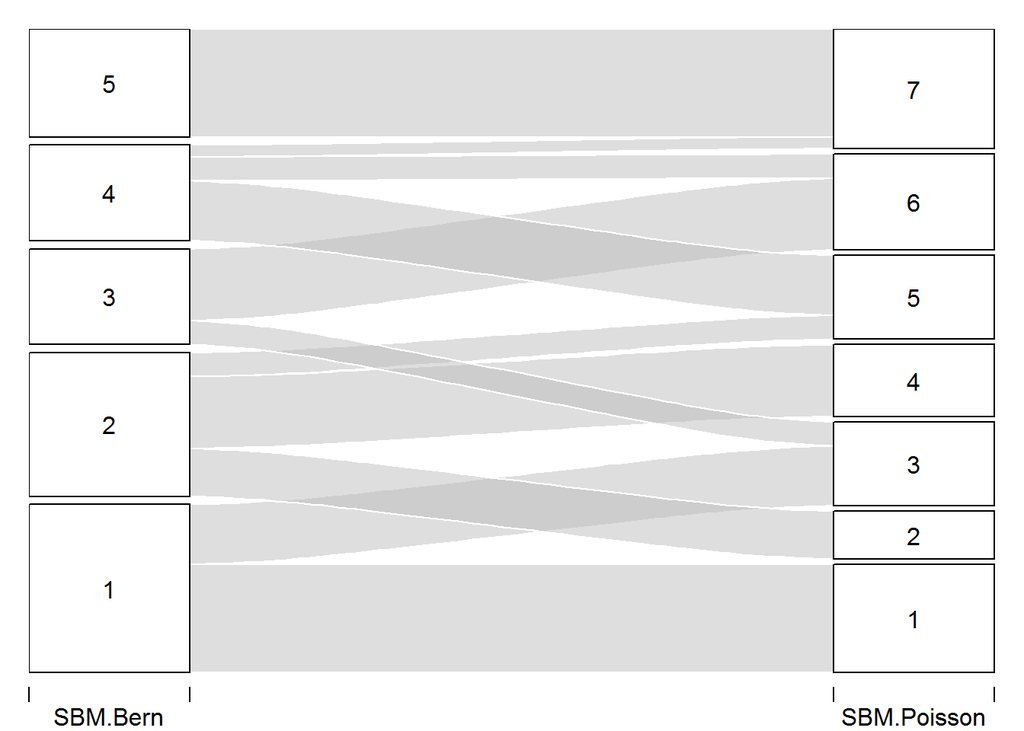

```r
A <- as.data.frame(table(sbm.tree_bin$memberships,sbm.tree$memberships))
colnames(A)=c('SBM Bern',"SBM Poisson","Freq")
w   <- which(A$Freq!=0)
A <- A[w,]
alluvial(A[,c(1,2)],freq=A$Freq)
```

# SBM for Counting Network with covariates

## Dataset : weighted tree-tree interactions with covariates

We have on each pair of trees 3 covariates, namely the genetic distance, the taxonomic distance and the geographic distance.

Each covariate has to be introduced as a matrix: $X^k_{ij}$ corresponds to the value of the $k$-th covariate describing the couple $(i,j)$.

## Model and inference

We can also use the Blockmodels package to estimate the parameters described previously.

$$\begin{align*}
(Z_i) \text{ i.i.d.} \qquad & Z_i \sim \mathcal{M}(1, \pi) \\
(Y_{ij}) \text{ indep.} \mid (Z_i) \qquad & (Y_{ij} \mid Z_i=k, Z_j = \ell) \sim \mathcal{P}(\exp(\alpha_{kl} + x_{ij}^\intercal \theta)) = \mathcal{P}(\lambda_{kl}\exp(x_{ij}^\intercal \theta))
\end{align*}$$

```r
sbm.cov <- estimateSimpleSBM(netMat =tree,model = 'poisson',directed =FALSE, covariates  = ListVar)
```

```
## -> Estimation for 1 groups
##
```

```
## -> Computation of eigen decomposition used for initalizations
##
## -> Pass 1
##     -> With ascending number of groups
##         -> For 2 groups
##
```

```
##         -> For 3 groups
##
```

```
##         -> For 4 groups
##
```

```
##         -> For 5 groups
##
```

```
##         -> For 6 groups
##
```

```
##     -> With descending number of groups
##         -> For 5 groups
##
```

```
##         -> For 4 groups
##
```

```
##         -> For 3 groups
##
```

```
##         -> For 2 groups
##
```

```
## -> Pass 2
##     -> With ascending number of groups
##         -> For 2 groups
##         -> For 3 groups
##
```

```
##         -> For 4 groups
##
```

```
##         -> For 5 groups
##         -> For 6 groups
##     -> With descending number of groups
##         -> For 5 groups
##         -> For 4 groups
##         -> For 3 groups
##         -> For 2 groups
## -> Pass 3
##     -> With ascending number of groups
##         -> For 2 groups
##         -> For 3 groups
##         -> For 4 groups
##         -> For 5 groups
##         -> For 6 groups
##     -> With descending number of groups
##         -> For 5 groups
##         -> For 4 groups
##         -> For 3 groups
##         -> For 2 groups
```

- We select the best number of clusters (with respect to the ICL criteria)

```r
Q <- sbm.cov$nbBlocks
Q
```

```
## [1] 4
```

- We can now extract the parameters of interest, namely ($\lambda$, $\pi$) and the clustering of the nodes.

```r
sbm.cov$connnectParam
```

[output not shown]

```r
sbm.cov$blockProp
```

```
## [1] 0.3715916 0.2159544 0.2354113 0.1770428
```

```r
sbm.cov$memberships
```

```
##  [1] 1 1 2 1 2 2 4 4 2 1 3 1 1 1 1 2 1 2 3 3 2 1 2 1 3 3 2 1 3 2 3 1 4 1 1 3 1 3
## [39] 4 1 1 3 2 4 4 1 4 4 3 3 4
```

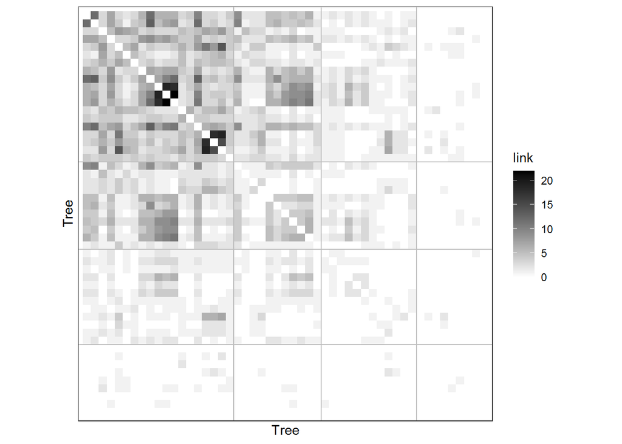

```r
plot(sbm.cov,type='data', ordered = TRUE, colLabel = 'Tree', rowLabel = 'Tree')
```

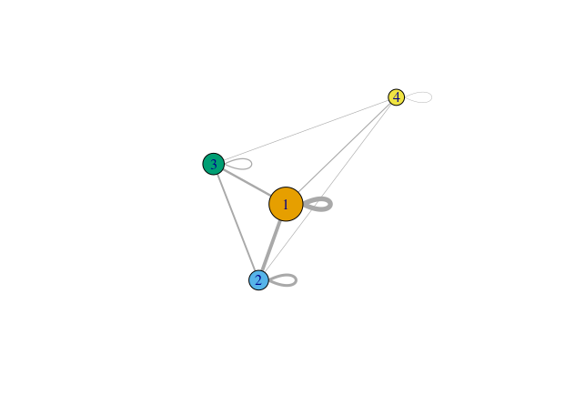

```r
G <- graph_from_adjacency_matrix(sbm.cov$connectParam$mean, mode = c("undirected"), weighted = TRUE, diag = TRUE)
plot.igraph(G,vertex.size = sbm.cov$blockProp*100,edge.width=sqrt(abs(E(G)$weight)),vertex.color = 1:sbm.cov$nbBlocks, layout = layout_nicely)
```

- The composition of the clusters/blocks are given by:

```r
lapply(1:sbm.cov$nbBlocks,function(q){tree_list[sbm.cov$memberships == q]})
```

```
## [[1]]
##  [1] Abies alba
##  [2] Abies grandis
##  [3] Large Maples (Acer platanoides, Acer pseudoplatanus)
##  [4] Cedrus spp (Cedrus atlantica, Cedrus libani)
##  [5] Fagus silvatica
##  [6] Fraxinus spp (Fraxinus angustifolia, Fraxinus excelsior)
##  [7] Juglans spp (Juglans nigra, Juglans regia)
##  [8] Larix decidua
##  [9] Picea excelsa
## [10] Pinus nigra laricio
## [11] Pinus pinaster
## [12] Pinus sylvestris
## [13] Cultivated Poplars (Populus trichocarpa, P. canescens, P.alba, P.nigra and their cultivated hybrids)
## [14] Prunus avium
```

[output cut: 47 more lines]

We are interested in comparing the three cluterings. To do so we use the alluvial flow plots

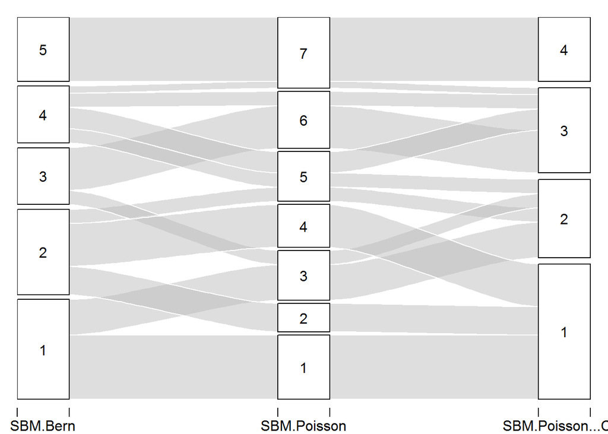

```r
B <- as.data.frame(table(sbm.tree_bin$memberships,sbm.tree$memberships,sbm.cov$memberships))
colnames(B) = c('SBM Bern',"SBM Poisson","SBM Poisson + Cov","Freq")
w   <- which(B$Freq != 0)
B <- B[w,]
alluvial(B[,c(1,2,3)],freq = B$Freq)
```

# Latent Block model

## Dataset : fungus-tree interactions

In the fungi-tree interactions network, an edge indicates if a tree species hosts a fungal species.

- Plot of the incidence matrix

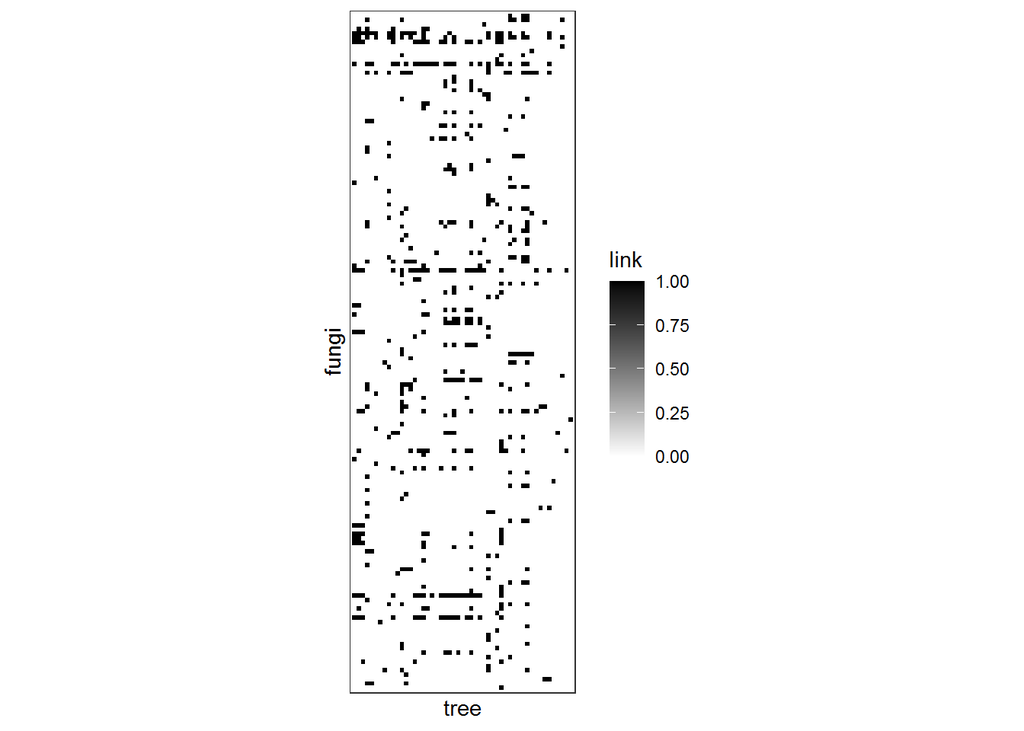

```r
plotMyMatrix(Mat = fungi_tree,rowLabel = 'fungi', colLabel  = 'tree')
```

We can know try to get a clustering of fungus and tree species conjointly.

## Model and inference

$$\begin{align*}
(Z^R_i) \text{ i.i.d.} \qquad & Z^R_i \sim \mathcal{M}(1, \pi^R) \\
(Z^C_i) \text{ i.i.d.} \qquad & Z^C_i \sim \mathcal{M}(1, \pi^C) \\
(Y_{ij}) \text{ indep.} \mid (Z^R_i, Z^C_j) \qquad & (Y_{ij} \mid Z^R_i=k, Z^C_j = \ell) \sim \mathcal{B}(\alpha_{k\ell})
\end{align*}$$

```r
lbm <- estimateBipartiteSBM(as.matrix(fungi_tree),model = 'bernoulli')
```

```
## -> Estimation for 2 groups (1+1)
##
```

```
## -> Computation of eigen decomposition used for initalizations
##     -> for rows
##     -> for cols
##
## -> Pass 1
##     -> With ascending number of groups
##         -> For 3 groups
##
```

```
##         -> For 4 groups
##
```

```
##         -> For 5 groups
##
```

```
##         -> For 6 groups
##
```

```
##         -> For 7 groups
##
```

```
##         -> For 8 groups
##
```

```
##         -> For 9 groups
##
```

```
##         -> For 10 groups
##
```

```
##         -> For 11 groups
##
```

```
##         -> For 12 groups
##
```

```
##         -> For 13 groups
##
```

```
##         -> For 14 groups
##
```

```
##     -> With descending number of groups
##         -> For 13 groups
##
```

```
##         -> For 12 groups
##
```

```
##         -> For 11 groups
##
```

```
##         -> For 10 groups
##
```

```
##         -> For 9 groups
##
```

```
##         -> For 8 groups
##
```

```
##         -> For 7 groups
##
```

```
##         -> For 6 groups
##
```

```
##         -> For 5 groups
##
```

```
##         -> For 4 groups
##
```

```
##         -> For 3 groups
##
```

```
## -> Pass 2
##     -> With ascending number of groups
##         -> For 3 groups
##         -> For 4 groups
##         -> For 5 groups
##
```

```
##         -> For 6 groups
##
```

```
##         -> For 7 groups
##
```

```
##         -> For 8 groups
##
```

```
##         -> For 9 groups
##
```

```
##         -> For 10 groups
##
```

```
##         -> For 11 groups
##
```

```
##         -> For 12 groups
##
```

```
##         -> For 13 groups
##
```

```
##         -> For 14 groups
##
```

```
##     -> With descending number of groups
##         -> For 13 groups
##
```

```
##         -> For 12 groups
##         -> For 11 groups
##         -> For 10 groups
##         -> For 9 groups
##
```

```
##         -> For 8 groups
##
```

```
##         -> For 7 groups
##
```

```
##         -> For 6 groups
##
```

```
##         -> For 5 groups
##         -> For 4 groups
##         -> For 3 groups
## -> Pass 3
##     -> With ascending number of groups
##         -> For 3 groups
##         -> For 4 groups
##         -> For 5 groups
##         -> For 6 groups
##         -> For 7 groups
##         -> For 8 groups
##
```

```
##         -> For 9 groups
##
```

```
##         -> For 10 groups
##
```

```
##         -> For 11 groups
##         -> For 12 groups
##         -> For 13 groups
##         -> For 14 groups
##     -> With descending number of groups
##         -> For 13 groups
##         -> For 12 groups
##         -> For 11 groups
##         -> For 10 groups
##         -> For 9 groups
##         -> For 8 groups
##         -> For 7 groups
##         -> For 6 groups
##         -> For 5 groups
##         -> For 4 groups
##         -> For 3 groups
```

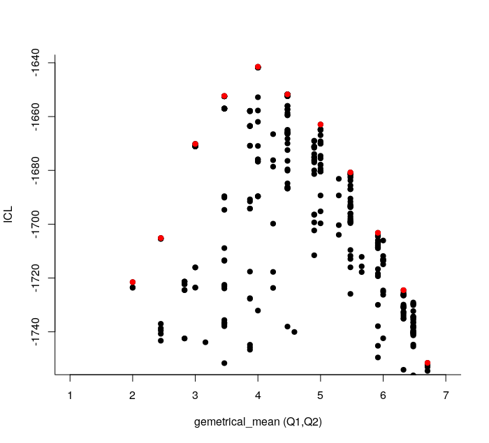

- We select the best number of clusters (with respect to the ICL criteria)

```r
lbm$nbBlocks
```

```
## row col
##   4   4
```

- We can extract the parameters of interest, namely ($\alpha$, $\pi$) and the clustering of the nodes.

```r
lbm$blockProp
```

```
## $row
## [1] 0.02655516 0.05570334 0.31666508 0.60107642
##
## $col
## [1] 0.1050494 0.1963968 0.2477304 0.4508234
```

```r
lbm$connectParam
```

```
## $mean
##            [,1]        [,2]        [,3]        [,4]
## [1,] 0.96813478 0.077538579 0.840370657 0.067563355
## [2,] 0.52055882 0.584398216 0.230893917 0.107930384
## [3,] 0.32450427 0.003624764 0.098526840 0.005780612
## [4,] 0.01834547 0.154334411 0.001330278 0.019219920
```

```r
lbm$memberships$row
```

```
##   [1] 4 4 4 3 2 2 1 4 4 4 4 2 4 2 3 3 3 3 4 4 3 3 3 4 4 3 4 3 3 4 4 4 4 4 3 3 3
##  [38] 4 3 4 4 4 4 4 4 4 4 2 2 4 4 4 4 4 3 4 2 3 1 4 3 4 3 3 4 3 3 3 3 3 3 4 3 4
##  [75] 4 3 4 4 4 4 4 3 4 3 4 4 4 3 4 4 2 3 4 4 4 3 4 3 3 2 3 3 4 3 4 4 4 4 4 4 4
## [112] 4 4 4 4 4 3 3 3 3 3 3 4 4 3 4 4 4 4 4 3 3 1 4 4 3 4 1 4 4 4 4 4 4 4 3 4 3
## [149] 4 4 4 4 4 3
```

```r
lbm$memberships$col
```

```
##  [1] 3 3 3 2 4 4 4 4 2 3 4 2 2 2 3 3 1 3 4 4 3 1 3 1 3 4 3 1 3 3 4 2 4 2 1 4 2 4
## [39] 4 2 2 4 4 4 4 4 4 4 4 4 4
```

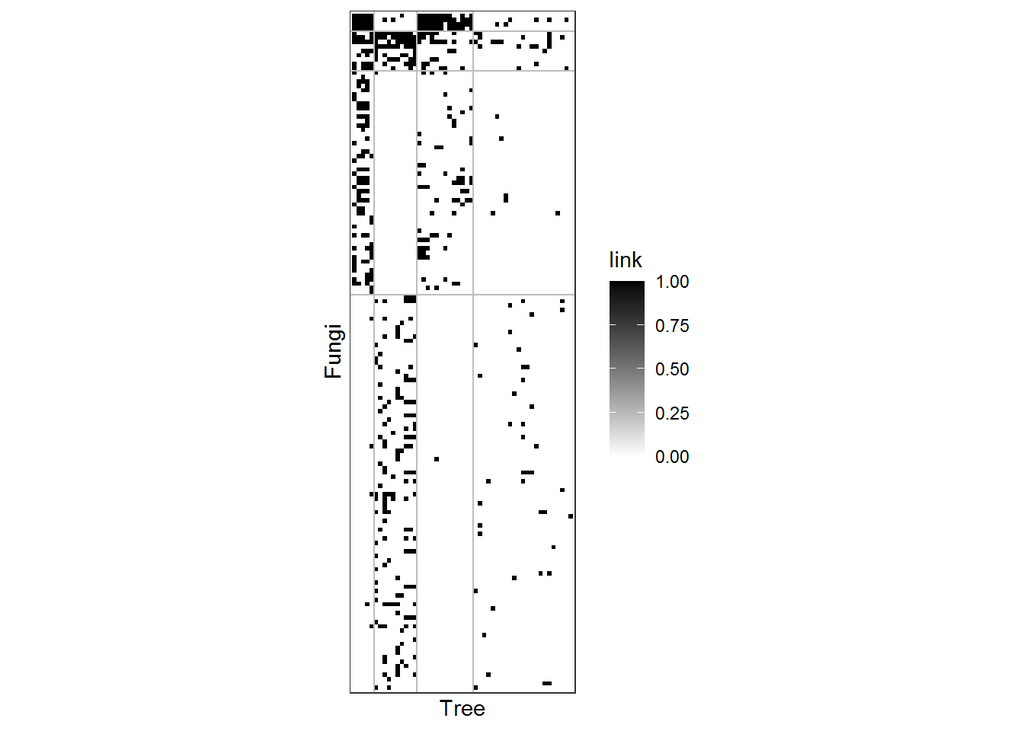

```r
plot(lbm, type ='data',ordered= TRUE, rowLabel = 'Fungi', colLabel = 'Tree')
```

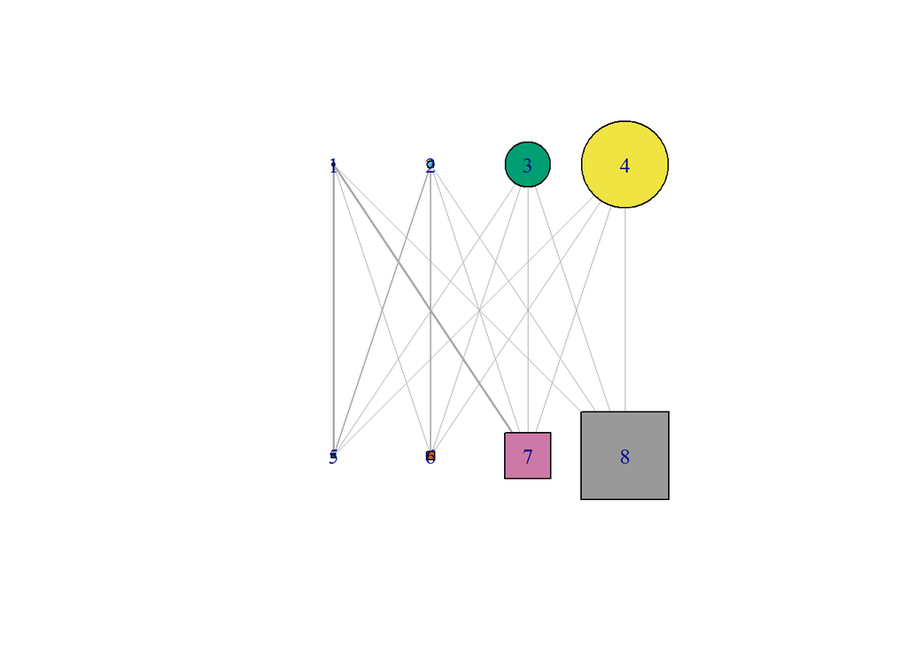

```r
G <- graph_from_incidence_matrix(lbm$connectParam$mean, weighted = TRUE)
plot(G,vertex.size=c(lbm$blockProp$row*100, lbm$blockProp$row*100), vertex.shape=c("circle", "square")[V(G)$type +1], edge.width=abs(E(G)$weight*2),vertex.color=1:sum(lbm$nbBlocks), layout=layout.bipartite)
```

- Exercise : give the name list of the various clusters.